# Visualizing Ocean Data on Reconstructed pH and Coral Bleaching Reports

## By: Stephen Tennyson

# Introduction

When we think of coral reefs we are reminded of some of our planet’s most beautiful yet delicate creatures, the coral. Capable of creating immense 3D structures in the water column, coral reefs support huge ecosystems for marine life with their calcium carbonate skeletons. However, these coral reefs are highly sensitive to our changing climate and according to past data presented here, *our coral reefs are in trouble*.

In this tutorial I will run publicly available data collected from coral reefs through a data science pipeline, applying principles such as linear regression, polynomial regression, multivariate regression, correlation, and machine learning. In the end I hope to draw conclusions on the importance of water parameters on coral health and make predictions about where our oceans are headed.

# Background

### What is a Coral?

A coral is actually not a plant, it is an animal. Coral are marine invertebrates which are usually colonial but can also be solitary specimens. Coral have fleshy bodies and (aside from soft coral) will build a hard skeleton that helps them filter food from the water column. Colonial coral are composed of several individual "coral units" called polyps, which have tentacles and a mouth to hunt for food items. There is a wide variety of coral, which can generally be classified into the following types:

- SPS - Small Polyp Stony coral, often considered 'Reef-building coral'
- LPS - Large Polyp Stony coral
- Soft coral
- NPS - Non-photosynthetic coral

### What is Ocean pH and why is it so important to coral?

pH is a chemical measurement of how acidic a solution is; So when we are talking about declining ocean pH, we are referring to **ocean acidification**. The pH scale ranges from 0 – 14 and is logarithmic, so a change of pH by 1 unit results in a relatively large change in the acidity of a solution. For this reason, we measure pH with precision to the hundredths place, for example 8.03.

In general, reef aquariums and ocean pH should be kept between 8.0 to 8.3. When pH dips below 8.0, the coral’s ability to calcify and create its carbonate skeleton become compromised. For a more detailed look on pH check out the video below by Bulk Reef Supply discussing pH in growing reef in a captive environment.

[video not shown]

### What is Coral Bleaching and why is it bad?

Reef-building coral rely on a symbiotic relationship they have with algae living inside their flesh called **zooxanthellae**. Zooxanthellae give coral the brown coloration of a healthy specimen and provide nutrients to the coral through photosynthesis. The algae gets a safe haven and protection by living inside the coral, the coral in return gets nutrients from the zooxanthellae.

When water parameters such as temperature and pH go out of wack, this symbiotic bond between the coral and its zooxanthellae is broken. The zooxanthellae are expelled from the coral, leaving nothing behind but a bleached-white coral unable to feed off of sunlight. Bleached coral are still alive and can recover, but they can just as easily die due to being starved by the deprivation of their symbiotic algae.

# Getting Started

Python 3 is used along with the following imports and libraries, grouped by the task for which they were intended.

```python
# Web scraping imports
import sys
!{sys.executable} -m pip install html5lib
import requests
from bs4 import BeautifulSoup

# Dataframe and analysis imports
import numpy as np
import pandas
import re
import matplotlib.pyplot as plt
from scipy.stats import spearmanr
import seaborn as sb

# Mapping coordinate data
!pip install folium
import folium
from folium.plugins import MarkerCluster
from folium.plugins import FastMarkerCluster
from folium.plugins import HeatMap
from folium.map import *

# Linear and Polynomial Regression
from sklearn import linear_model
from sklearn.preprocessing import PolynomialFeatures
from sklearn.metrics import mean_squared_error, r2_score
from sklearn.linear_model import LinearRegression
```

# Sources of Data Used in this Tutorial

## (1) Evidence for ocean acidification in the Great Barrier Reef of Australia

The first dataset by Wei et. al, 2009 (1) analyzed reconstructed ocean pH dating back to 1807 up until 2004. This was done by using isotopic analysis on the coral skeletons of Porites collected from the Great Barrier Reef of Australia. Although these reconstructed water parameters are mere predictors of what our oceans were like back then, these coral skeletons serve as an indispensable tool in defining how our oceans were before human activity impacted our planet.

### Isotopes and Minerals Analyzed

- d11B isotope used to reconstruct Ocean pH
- d13C isotope for carbon composition
- Magnesium to Calcium ratio
- Strontium to Calcium ratio
- Barium to Calcium ratio

The highlight of this study are the d11B and d13C isotopic data. By using mathematical formulas, scientists were able to predict with high precision what the oceanic pH was during a specific year, dating back up to 200 years. The d13C value, while not described in much detail from the source, is likely a measure of the carbon density within the coral. Since coral base their skeleton from carbonate (HCO3-), the assumption I made here is that d13C is a measure of carbonate density of the coral skeleton for the predicted year. *The researchers assert that d13C is a measure of the predicted oceanic CO2, but whether the C13 within the coral skeleton accurately predicts atmospheric CO2 levels lies outside the scope of this tutorial*. The other values predicted are for Magnesium, strontium, and barium, which are common components of coral skeletons and also provide a window into what our ocean chemistry was like through the years.

## (2) A new, high-resolution global mass coral bleaching database.

The second dataset by Donner et al., 2017 (2) collected over 7000 coral reef bleaching events around the globe, creating one of the largest reef bleaching databases ever created. This exhaustive record of bleaching events tracks the location, coordinates, month, year, depth and severity of reports made by research institutions or submitted voluntarily. This database rates the severity of each report from -1 to 3 following the key below.

### Severity key

- -1 : Unknown
- 0 : No bleaching
- 1 : Mild (1-10% bleaching)
- 2: Moderate (11-50% bleached)
- 3: Severe (>50% bleached)

# Data Preprocessing

Data from both sources (1) and (2) are publically available for download, *citations given at the bottom of this page*. On the source page you can find download links for the data as an Excle file.

## Data Extraction - (1) Wei et al., 2009

For the first study I demonstrated python's ability to extract text from the data in html format using **web scraping and parsing** in Python.

```python
# Send an html request and parse using beautifulSoup
URL ="https://www.ncei.noaa.gov/pub/data/paleo/coral/west_pacific/great_barrier/wei2009_noaa.txt"
headers = {"user-agent": "Mozilla/5.0 (Macintosh; Intel Mac OS X x.y; rv:42.0) Gecko/20100101 Firefox/42.0"}
r = requests.get(URL, headers = headers)
html = r.content
# Run beautiful soup on html
root = BeautifulSoup(html, 'html.parser')

# Extract the data
# Since there is no table in this html, use a regexp to find character range where data begins
rootstr = str(root)
match = re.search(r"AREO", rootstr, re.M)
start = match.start()
# Find the range of characters we want
datastr = rootstr[start:len(rootstr)]
datastr = datastr.split('\n')

# Put string rows into dataframe df
df = pandas.DataFrame(datastr)
# Split each row using '\t' delimiter and expand into columns
df = df[0].str.split('\t',expand=True)
df.columns = ['sampage', 'd18O', 'Sr/Ca', 'd13C', 'Mg/Ca', 'Ba/Ca', 'd11B', 'd11B_2s', 'pH', 'pH_2s', 'unlabeled']
# Split first column further by space delimiter
tempdf = df['sampage'].str.split(' ',expand=True)
tempdf.columns = ['samp','age']
# Organize the dataframe df a bit
df = df.drop(['sampage', 'unlabeled'], axis=1)
df = pandas.merge(tempdf, df, left_index=True, right_index=True)
# Cast the data of interest to floats so we can work with it
df = df.astype({"samp":str, "age":str, "d18O":int, "Sr/Ca":float,
                "d13C":float, "Mg/Ca":float, "Ba/Ca":float, "d11B":float,
                "d11B":float, "d11B_2s":float, "pH":float, "pH_2s":float})

df.head(5)
```

|  | samp | age | d18O | Sr/Ca | d13C | Mg/Ca | Ba/Ca | d11B | d11B_2s | pH | pH_2s |
| --- | --- | --- | --- | --- | --- | --- | --- | --- | --- | --- | --- |
| 0 | AREO | 4-1805-09 | 1807 | -4.40 | 7.762 | -1.59 | 4.310 | 3.53 | 23.61 | 0.16 | 8.02 |
| 1 | AREO | 4-1810-14 | 1812 | -4.49 | 7.910 | -2.00 | 4.139 | 4.03 | 24.53 | 0.15 | 8.13 |
| 2 | AREO | 4-1815-19 | 1817 | -4.56 | 7.773 | -1.47 | 4.302 | 3.36 | 22.74 | 0.15 | 7.90 |
| 3 | AREO | 4-1820-24 | 1822 | -4.49 | 7.792 | -1.25 | 4.101 | 3.71 | 23.86 | 0.16 | 8.05 |
| 4 | AREO | 4-1825-29 | 1827 | -4.37 | 7.745 | -1.36 | 4.249 | 3.31 | 24.77 | 0.12 | 8.15 |

In the above dataframe using pandas we display the first 5 rows for ease of viewing. The data we will be looking at for this analysis are

- d18O: Isotopically predicted year
- Sr/Ca: Strontium to Calcium
- Mg/Ca: Magnesium to Calcium
- Ba/Ca: Barium to Calcium
- d13C: Carbon content of coral
- pH_2s: Predicted Ocean pH

## Data Extraction - (2) Donner et al., 2017

For the second study the data was uploaded directly from an excel file and transferred into a pandas dataframe.

```python
# Read the excel file and cast the GPS coordinates to type float for later use
datafile = pandas.read_excel('BleachingdatabaseV1.0.xlsx')
datafile["LATITUDE"] = datafile["LATITUDE"].astype(float)
datafile["LONGITUDE"] = datafile["LONGITUDE"].astype(float)
datafile["YEAR"] = datafile["YEAR"].astype(int)
datafile.head(3)
```

|  | COUNTRY | LOCATION | SITE_NAME | LATITUDE | LONGITUDE | MONTH | YEAR | DEPTH | SEVERITY_CODE | PERCENT_BLEACHED | MORTALITY_CODE | PERCENT_MORTALITY | SURVEY_TYPE | SOURCE | NAME | CITATION | COMMENTS | ENTRY_CODE | DATABASE_CODE |
| --- | --- | --- | --- | --- | --- | --- | --- | --- | --- | --- | --- | --- | --- | --- | --- | --- | --- | --- | --- |
| 0 | Jamaica | Jamaica | NaN | 18.200000 | -77.250000 | NaN | 1963 | NaN | -1 | NaN | NaN | NaN | NaN | ReefBase | NaN | NaN | Some of the surviving corals bleached (Goreau,... | NaN | 1 |
| 1 | Puerto Rico | Puerto Rico | NaN | 17.866667 | -66.433333 | NaN | 1969 | NaN | -1 | NaN | NaN | NaN | NaN | ReefBase | NaN | NaN | An intensive and extensive bleaching event occ... | NaN | 1 |
| 2 | Colombia | Providencia Island ( Isla de Providencia ) | NaN | 13.358333 | -81.383333 | NaN | 1969 | 1-20 m | -1 | NaN | NaN | NaN | NaN | ReefBase | NaN | NaN |  | NaN | 1 |

# Visualizing the Data

## Coral Bleaching Reports

Briefly we will show the number of mass coral bleaching reports from the second dataset before exploring reconstructed water chemistry levels.

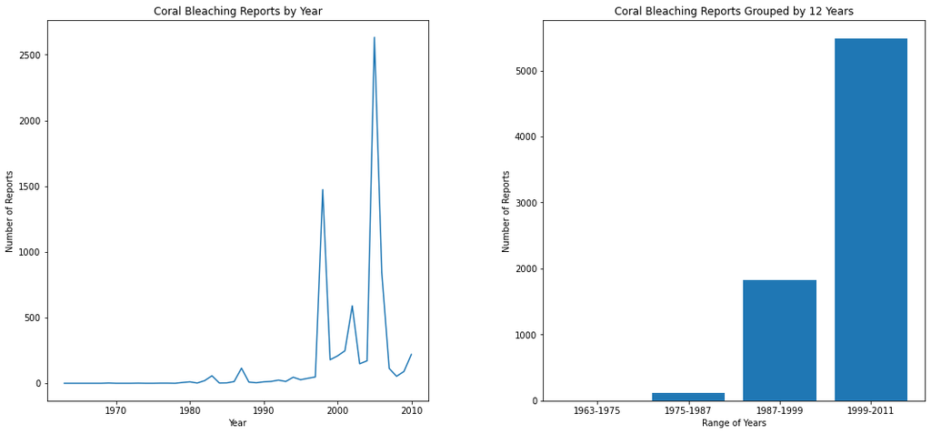

```python
# The purpose of this function is to create a list of ranges so we can easily do aggregates on different ranges of years denoted by iterator
# ie. create_ranges(1963, 2012, 12) will create a list of 12 ranges between 1963 -2012
# ie. passing in 1 as the iterator will do yearly ranges to view all data
def create_ranges(start, end, iterator):
    # Create an index for the range the data spans
    ranges = list(range(start,end,iterator))
    # Create a tuple for ranges (allows us to do aggregates by year)
    range_arr = []
    for i in range(0, len(ranges) - 1):
        npele = (ranges[i], ranges[i+1])
        range_arr.append(npele)
    return range_arr

def sum_reports(range_arr, print_output):
    numevents = []
    year = []
    for i in range(0, len(range_arr)):
        count = 0
        start = range_arr[i][0]
        end = range_arr[i][1]
        for j in range(1, len(datafile)):
            if datafile.YEAR[j] in range(start,end):
                count = count + 1
        year.append(start)
        numevents.append(count)
        if print_output == True:
            print("{} - {}: {}".format(start, end, count))
    return year, numevents

# Generate plot for yearly data, do not show raw output
range_yearly = create_ranges(1963, 2012, 1)
year_yearly, numevents_yearly = sum_reports(range_yearly, False)

# Generate plot for the 48 year range of data in 12 groups
ranges = create_ranges(1963,2012,12)
year_range, numevents_range = sum_reports(ranges, False)

fig, (ax1,ax2) = plt.subplots(1,2)
fig.set_figheight(8)
fig.set_figwidth(18)
fig.subplots_adjust(wspace=0.30, hspace=0.4)

# Plot the yearly data as a line plot
a1 = ax1.plot(year_yearly, numevents_yearly)
ax1.set(ylabel ='Number of Reports', xlabel = 'Year')
ax1.set_title('Coral Bleaching Reports by Year')

# Plot the 12-year range data as a bar plot
nums = ['1963-1975', '1975-1987','1987-1999','1999-2011']
a2 = ax2.bar(nums, numevents_range)
ax2.set(ylabel ='Number of Reports', xlabel = 'Range of Years')
ax2.set_title('Coral Bleaching Reports Grouped by 12 Years')
```

Notice a considerable increase in the number of coral bleaching reports in year 1998 and 2005. The data here is displayed both as a line graph showing yearly number of reports, and a bar graph for an aggregate (sum) across 12 years.

## Mapping Coral Bleaching Reports

- This interactive map shows a heatmap of all bleaching reports from the entire dataset. Here we hope to show the entire scope of where data has been collected from on our ocean's reefs.

```python
map_osm3 = folium.Map(location=[10.490000, 1.75000], zoom_start=1)
HeatMap(datafile[['LATITUDE', 'LONGITUDE']].values.tolist()).add_to(map_osm3)
map_osm3
```

Make this Notebook Trusted to load map: File -> Trust Notebook

[interactive chart not shown]

### Plotting coordinates of coral bleaching reports prior to 1987

- This interactive map allows you to zoom in on the world map and see clusters of bleaching reports between 1963 and 1987. Notice that the reports over this 24 year period are few and far between.
- Clicking on each marker displays selected data from each report.

```python
# init map
map_osm1 = folium.Map(location=[10.490000, 1.75000], zoom_start=2)
# Create marker clusters for easier viewing
marker_cluster1 = MarkerCluster().add_to(map_osm1)
# Iterate through data points and plot data before 1987
for i in range(1, len(datafile)):
    # Display marker for Male
    if datafile.YEAR[i] <= 1987:
        # In popup also display date, age, race and specify icon and color for Male
        folium.Marker([datafile.LATITUDE[i], datafile.LONGITUDE[i]],
                      popup = 'Year:{}\nLocation:{}\nSeverity:{}\nSource:{}\nComments:{}'.format(
                          datafile.YEAR[i], datafile.LOCATION[i],
                          datafile.SEVERITY_CODE[i],
                          datafile.SOURCE[i], datafile.COMMENTS[i]),
                      icon = folium.Icon(color = 'darkblue', icon_color='white',
                      icon='skull-crossbones', angle=0, prefix ='fa')).add_to(marker_cluster1)

map_osm1
```

Make this Notebook Trusted to load map: File -> Trust Notebook

[interactive chart not shown]

Coral bleaching reports prior to 1987

```python
range_arr = create_ranges(1963, 2012, 12)


mapa = folium.Map()

for i in range(0, len(range_arr)):
    count = 0
    start = range_arr[i][0]
    end = range_arr[i][1]
    period ='{} to {}'.format(start,end)
    feature_group = FeatureGroup(name = period, show = True)
    for j in range(1, len(datafile)):
        if datafile.YEAR[j] in range(start,end) and datafile.SEVERITY_CODE[j] == 3:
            count = count + 1
            feature_group.add_child(Marker(location = (datafile.LATITUDE[j], datafile.LONGITUDE[j]),
                                           popup = 'Year:{}\nLoc:{}\nSeverity:{}\n'.format(
                          datafile.YEAR[j], datafile.LOCATION[j],
                          datafile.SEVERITY_CODE[j])))

    mapa.add_child(feature_group)

print(count)
mapa.add_child(folium.map.LayerControl())
mapa
```

```
1407
```

Make this Notebook Trusted to load map: File -> Trust Notebook

[interactive chart not shown]

## Reconstructed Ocean pH and Other Parameters

Below are figures showing the raw data of reconstructed pH, Magnesium, Strontium, Barium ratios, and Carbon composition

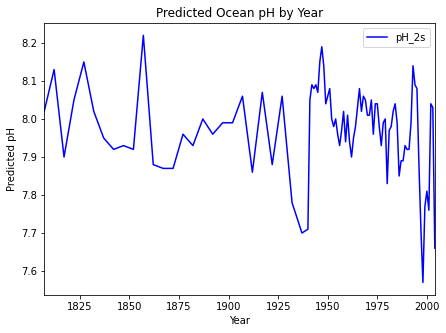

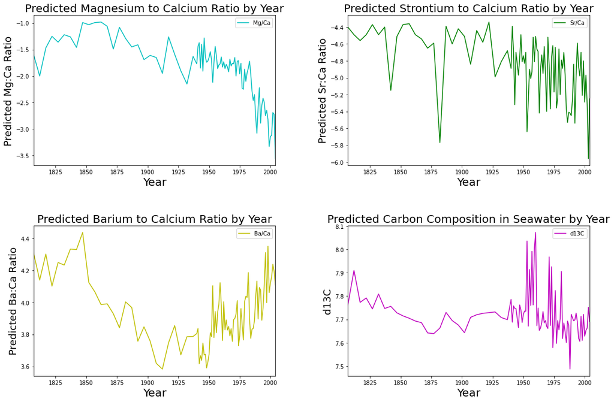

```python
def makeSubplot(xtitle, xvar, yvar, c, ytitle, title, xlim1, xlim2, ax0, ax1):
    p = df.plot(y=yvar, x=xvar, color=c, xlim =(xlim1,xlim2), ax=axes[ax0,ax1])
    p.set_xlabel(xtitle, fontsize=20)
    p.set_ylabel(ytitle, fontsize=18)
    p.set_title(title, fontsize=20)

# Set axes and title strings for figure as well as color
xtit = 'Year'
xvar = 'd18O'
yvar1 = 'pH_2s'
c1 = 'b'
ytit1 = 'Predicted pH'
t1 = 'Predicted Ocean pH by Year'
# Make the actual plot from the dataframe df and set titles
p1 = df.plot(y=yvar1, x = xvar, color = c1, xlim = (1807, 2004), figsize =(7,5))
p1.set_xlabel(xtit)
p1.set_ylabel(ytit1)
p1.set_title(t1)


# Create subplot for the other parameter figures
fig,axes = plt.subplots(2,2)
fig.set_figheight(12)
fig.set_figwidth(18)
fig.subplots_adjust(wspace=0.30, hspace=0.4)


# Repeat for the other water parameters provided
c2 = 'c'
t2 = 'Predicted Magnesium to Calcium Ratio by Year'
ytit2 ='Predicted Mg:Ca Ratio'
yvar2 = 'Mg/Ca'
makeSubplot(xtit, xvar, yvar2, c2, ytit2, t2, 1807, 2004, 0, 0)


c3 = 'g'
t3 = 'Predicted Strontium to Calcium Ratio by Year'
ytit3 = 'Predicted Sr:Ca Ratio'
yvar3 = 'Sr/Ca'
makeSubplot(xtit, xvar, yvar3, c3, ytit3, t3, 1807, 2004, 0, 1)


c4 = 'y'
t4 = 'Predicted Barium to Calcium Ratio by Year'
ytit4 = 'Predicted Ba:Ca Ratio'
yvar4 = 'Ba/Ca'
makeSubplot(xtit, xvar, yvar4, c4, ytit4, t4, 1807, 2004, 1, 0)


c5 = 'm'
t5 = 'Predicted Carbon Composition in Seawater by Year'
ytit5 = 'd13C'
yvar5 = 'd13C'
makeSubplot(xtit, xvar, yvar5, c5, ytit5, t5, 1807, 2004, 1, 1)
```

- There appears to be an overall trend for declining parameters across all measurements with an oscillatory nature (some years a sharp increase followed by a sharp decrease) and this may indicate natural cycles in the ocean that affect these parameters by years and possibly decadal oscillations in the Pacific Ocean.
- The figures shown above become suddenly noisy after 1940. This is because prior to 1940 samples were taken every 5 years. After 1940, samples were taken every year providing higher resolution on the data.

## Visualizing Both Datasets Together

To give us a better idea on the precision of the reconstructed pH values, lets see how the pH data aligns with world events by plotting it against the number of mass coral bleaching reports across years.

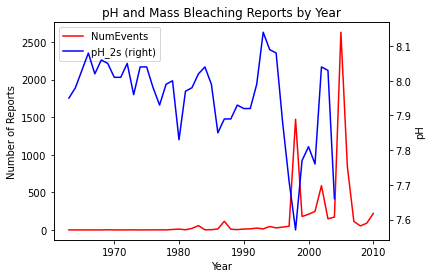

```python
# Transfer coral bleaching report data to a dataframe
altyears = list(range(1963,2011))
altdatadf = pandas.DataFrame(altyears)
altdatadf['numEvents'] = pandas.DataFrame(numevents_yearly)
altdatadf.columns = ['Year','NumEvents']
# Crop the data so that the years both start at 1963 which is the start of (2)'s data collection
cropdf = df[['d18O','pH_2s']].copy()
cropdf = cropdf[cropdf['d18O'] >= 1963]
cropdf = cropdf.reset_index()
cropdf.columns = ['idx','Year','pH_2s']
# Do a join to merge both datasets on year
merged_datasets = altdatadf.join(cropdf.set_index('Year'), on='Year')

# Plot the data with two y-axes for pH and Bleaching Reports
fig, ax = plt.subplots()
merged_datasets.plot(x = 'Year', y = 'NumEvents', ax=ax, style = 'r-')
merged_datasets.plot(x = 'Year', y = 'pH_2s', ax=ax, style='b-', secondary_y= True)
ax.set_ylabel('Number of Reports')
ax.right_ax.set_ylabel('pH')
ax.set_xlabel('Year')
ax.set_title('pH and Mass Bleaching Reports by Year')
```

# Exploratory Analysis on pH and Other Parameters

The following sections take the analysis on the raw data a step further by performing a series of regression modeling and correlations on the data for pH, strontium, magnesium, barium and carbon. Here we will do **linear regression**, **polynomial regression**, **correlation**, and **machine learning for multivariate regression**.

## Linear Regression

### The Code

```python
def makeLinReg(ef, xvar, yvar, ytit, title1, c, subplot, ax0, ax1):
    if subplot == True:
        e1 = ef.plot.scatter(x=xvar, y=yvar, title = title1, color = c, ax=axes[ax0,ax1])
        e1.set_xlabel('Year', fontsize=15)
        e1.set_ylabel(ytit, fontsize=15)
        e1.set_title(title1, fontsize= 20)

    else:
        e1 = ef.plot.scatter(x=xvar, y=yvar, title = title1, color = c)
        e1.set_xlabel('Year')
        e1.set_ylabel(ytit)
        e1.set_title(title1)


    # Extract data for the regression model below
    years = ef[xvar]
    yvariable = ef[yvar]
    # Convert year array into 2D array
    years = np.array([[h] for h in years])

    # Fit regression line to model
    model = linear_model.LinearRegression().fit(years, yvariable)
    e1.plot(years, model.predict(years), color = 'k')
    #print('Model Coefficient of Determination: ', model.score(years, yvariable))
    printedmodel = 'Year' + '\n\nModel: ' + str(round(model.intercept_, 4)) + ' + ' + str(round(model.coef_[0],4)) + '*x'
    e1.set_xlabel(printedmodel)

    # Save the coefficients and return them
    coef = []
    coef.append(model.intercept_)
    coef.append(model.coef_[0])
    return coef
```

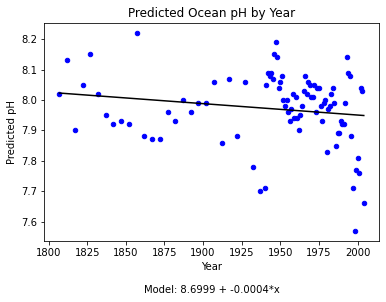

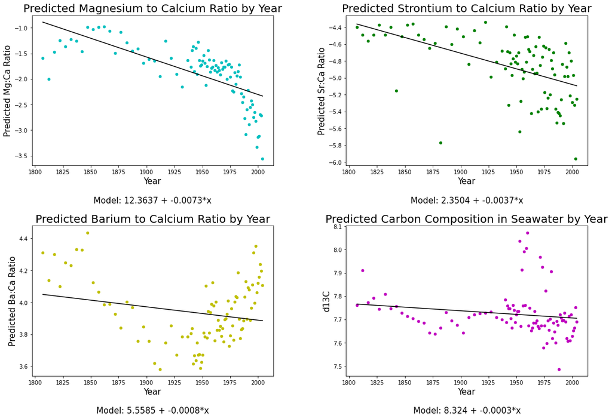

```python
coef1 = makeLinReg(df, 'd18O', 'pH_2s', ytit1, t1, c1, False, 0, 0)

# Create subplot for the other parameter figures
fig,axes = plt.subplots(2,2)
fig.set_figheight(12)
fig.set_figwidth(18)
fig.subplots_adjust(wspace=0.30, hspace=0.4)

coef2 = makeLinReg(df, 'd18O', 'Mg/Ca', ytit2, t2, c2, True, 0,0)
coef3 = makeLinReg(df, 'd18O', 'Sr/Ca', ytit3, t3, c3, True, 0,1)
coef4 = makeLinReg(df, 'd18O', 'Ba/Ca', ytit4, t4, c4, True, 1,0)
coef5 = makeLinReg(df, 'd18O', 'd13C', ytit5, t5, c5, True, 1,1)
```

### Linear Regression Results

- Here we have fitted a linear model to the different water parameter data. The x-axis is year, and y axis is pH, Mg/Ca, Sr/Ca, Ba/Ca and Carbon composition. The linear model is printed below each figure, and can be used to predict each water parameter for each year.
- Unfortunately for some parameters, the linear model does not appear to be a great fit, particularly for pH, Ba/Ca and Mg/Ca. Below we will try to get a better fit on the data with polynomial regression.

## Polynomial Regression

### The code

```python
def makePolyReg(ef, xvar, yvar, ytit, title1, c, d, subplot, ax0, ax1):
    if subplot == True:
        e1 = ef.plot.scatter(x=xvar, y=yvar, title = title1, color = c, ax=axes[ax0,ax1])
        e1.set_xlabel('Year', fontsize=15)
        e1.set_ylabel(ytit, fontsize=15)
        e1.set_title(title1, fontsize=20)
    else:
        e1 = ef.plot.scatter(x=xvar, y=yvar, title = title1, color = c)
        e1.set_xlabel('Year')
        e1.set_ylabel(ytit)
        e1.set_title(title1)

    # Extract data for the regression model below
    x = ef[xvar]
    y = ef[yvar]
    weights = np.polyfit(x,y, d)
    # If you want to see coefficients and their outputs for the specified degree
    #print(poly_feat.get_feature_names(yvar))
    #print(poly_feat.transform(x))

    counter = 0
    output = ""
    for i in range(d, -1, -1):
        if counter == 0:
            output = output + str(round(weights[i],2)) + " + "
        elif counter == 1:
            output = output + str(round(weights[i],2)) + "x + "
        elif counter in range(2, d):
            output = output + str(round(weights[i],2)) + "x^" + str(counter) + " + "
        elif counter == d:
            output = output + str(round(weights[i],2)) + "x^" + str(counter)
        counter = counter + 1

    printedmodel = "Model: " + output
    e1.set_xlabel("Year\n\n" + printedmodel)


    model = np.poly1d(weights)
    ypred = model(x)
    e1.scatter(x, y, color = c)
    e1.plot(x, ypred, color = 'k')
```

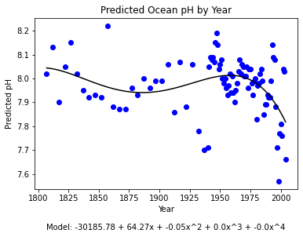

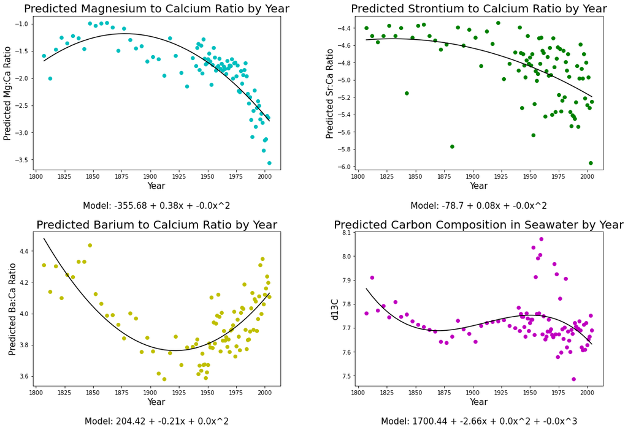

```python
makePolyReg(df, 'd18O', 'pH_2s', ytit1, t1, c1, 4, False, 0,0)

# Create subplot for the other parameter figures
fig,axes = plt.subplots(2,2)
fig.set_figheight(12)
fig.set_figwidth(18)
fig.subplots_adjust(wspace=0.30, hspace=0.4)

makePolyReg(df, 'd18O', 'Mg/Ca', ytit2, t2, c2, 2, True, 0,0)
makePolyReg(df, 'd18O', 'Sr/Ca', ytit3, t3, c3, 2, True, 0,1)
makePolyReg(df, 'd18O', 'Ba/Ca', ytit4, t4, c4, 2, True, 1,0)
makePolyReg(df, 'd18O', 'd13C', ytit5, t5, c5, 3, True, 1,1)
```

## Correlations between pH and other parameters

### The Code

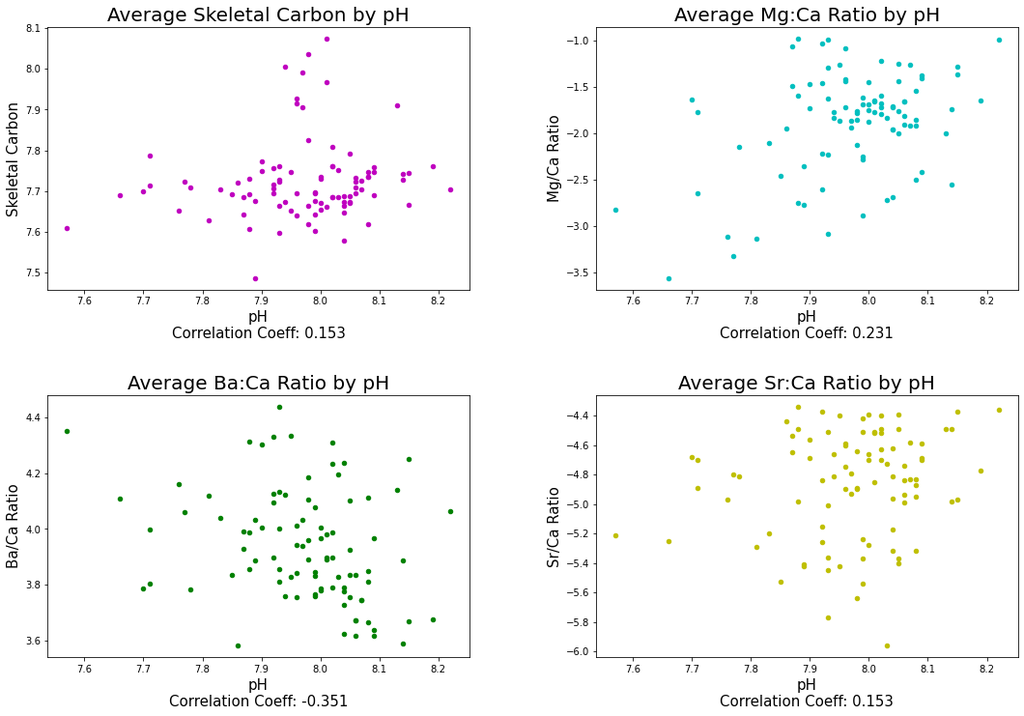

```python
def print_corr(x, y):
    corr1, _ = spearmanr(x,y)
    #print('Spearmans correlation: %.3f' % corr1)
    return round(corr1,3)


# Create subplot for the other parameter figures
fig_g,axes = plt.subplots(2,2)
fig_g.set_figheight(12)
fig_g.set_figwidth(18)
fig_g.subplots_adjust(wspace=0.30, hspace=0.4)

g1 = df.plot.scatter(x = 'pH_2s', y = 'd13C', color = c5, ax=axes[0,0])
corr = print_corr(df.pH_2s, df.d13C)
xlab = 'pH\nCorrelation Coeff: ' + str(corr)
g1.set_title('Average Skeletal Carbon by pH', fontsize=20)
g1.set_xlabel(xlab, fontsize=15)
g1.set_ylabel('Skeletal Carbon', fontsize=15)

g2 = df.plot.scatter(x = 'pH_2s', y = 'Mg/Ca', color = c2, ax=axes[0,1])
corr = print_corr(df.pH_2s, df['Mg/Ca'])
xlab = 'pH\nCorrelation Coeff: ' + str(corr)
g2.set_title('Average Mg:Ca Ratio by pH', fontsize=20)
g2.set_xlabel(xlab, fontsize=15)
g2.set_ylabel('Mg/Ca Ratio', fontsize=15)

g3 = df.plot.scatter(x = 'pH_2s', y = 'Ba/Ca', color = c3, ax=axes[1,0])
corr = print_corr(df.pH_2s, df['Ba/Ca'])
xlab = 'pH\nCorrelation Coeff: ' + str(corr)
g3.set_title('Average Ba:Ca Ratio by pH', fontsize=20)
g3.set_xlabel(xlab, fontsize=15)
g3.set_ylabel('Ba/Ca Ratio', fontsize=15)

g4 = df.plot.scatter(x = 'pH_2s', y = 'Sr/Ca', color = c4, ax=axes[1,1])
corr = print_corr(df.pH_2s, df['Sr/Ca'])
xlab = 'pH\nCorrelation Coeff: ' + str(corr)
g4.set_title('Average Sr:Ca Ratio by pH', fontsize=20)
g4.set_xlabel(xlab, fontsize=15)
g4.set_ylabel('Sr/Ca Ratio', fontsize=15)
```

## Machine Learning for Multivariate Regression

For machine learning we are going to use gradient descent to develop a multivariate formula used to predict pH values. The way this work is we run our algorithm a set amount of times (in this case either 200 or 1000 iterations) and it finds coefficients for the parameters that predict pH with the lowest cost.

### After 200 Iterations

```python
# Gradient descent function implementation with appropriate alpha value for reaching a minimum cost
def grad_descent(x, y, T, alpha, count, shortoutput):
    m,n = x.shape
    theta = np.zeros(n)
    f = np.zeros(T)
    # Iterate through the range T given
    print('Sample gradient descent values printed from first 3 iterations')
    for i in range(T):
        # Use a counter to display the first few iterations and not use up a bunch of pages
        count = count + 1
        # Print the cost of each movement during descent
        f[i] = 0.5*np.linalg.norm(x.dot(theta) - y)**2
        g = x.T.dot(x.dot(theta)-y)
        theta = theta - alpha*g
        if shortoutput == 'yes':
            if count < 3 or count > T - 2:
                # Print out important values
                print("Iteration: {}\nF[i]: {}\nG: {}\nTHETA: {}\n________________________________________________________".format(count, f[i], g, theta))
        else:
            # Print out important values
            print("F[i] {}, \nG\n{}\nTHETA\n{}\n".format(f[i], g, theta))
    return theta, f[i]
```

```
Sample gradient descent values printed from first 3 iterations
Iteration: 1
F[i]: 2923.93015
G: [-3568.6461  -5664.90161 -1379.8825  -2886.41534]
THETA: [0.35686461 0.56649016 0.13798825 0.28864153]
________________________________________________________
Iteration: 2
F[i]: 12.959255691038395
G: [-201.17101646 -329.12741092  -70.40112328 -165.62951679]
THETA: [0.37698171 0.5994029  0.14502836 0.30520449]
________________________________________________________
Iteration: 199
F[i]: 1.9249635671526308
G: [ 2.36024591 -2.89824602  5.08176248  0.3166919 ]
THETA: [0.31993992 0.67305884 0.00836385 0.30378818]
________________________________________________________
Iteration: 200
F[i]: 1.9209795072680613
G: [ 2.35518761 -2.89201634  5.06607868  0.31828398]
THETA: [0.3197044  0.67334804 0.00785725 0.30375635]
________________________________________________________
pH = 0.32208252*Sr + 0.67042778*d13C +0.01299445*Mg + 0.30406741*Ba
```

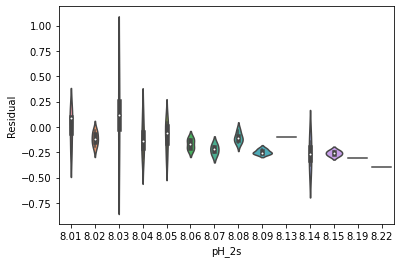

```python
coral_dat = df.drop(['samp','age','d18O','d11B','d11B_2s','pH','pH_2s'], axis=1)
pH = df.drop(['samp','age','d18O','d11B','d11B_2s','pH','Sr/Ca','d13C','Mg/Ca','Ba/Ca'], axis=1)
coral_dat = coral_dat.abs()

coral_dat = np.array(coral_dat)
pH = np.array(pH).squeeze()
pH = pH.tolist()
grad_descent(coral_dat, pH, 200, 0.0001, 0, 'yes')

a1 = 0.32208252
a2 = 0.67042778
a3 = 0.01299445
a4 = 0.30406741

df['Sr/Ca'] = abs(df['Sr/Ca'])
df['Mg/Ca'] = abs(df['Mg/Ca'])

df['PredictedpH'] = a1*(df['Sr/Ca']) + a2*(df['d13C']) + a3*(df['Mg/Ca']) + a4*(df['Ba/Ca'])
df['Residual'] = df['PredictedpH'] - df['pH_2s']



df['pH_Score'] = np.where(df['pH_2s'] > 8.0, 'High', 'Low')
tempdf = [x for _, x in df.groupby(by=["pH_Score"])]
highdf = tempdf[0]
l1 = sb.violinplot(x='pH_2s', y='Residual', data=highdf, figsize=(15,10))

print('pH = {}*Sr + {}*d13C +{}*Mg + {}*Ba'.format(a1, a2, a3, a4))
```

### Machine Learning Results After 200 Iterations

- Here we ran a machine learning algorithm predicted pH vs Carbon (d13C), Sr, Mg, and Ba ratios. Above we show the cost (F[i], step values (G) and resulting coefficients (Theta) after each iteration in our gradient descent algorithm using a least squares model for the descent.
- After so many iterations, the algorithm determines the coefficients that yield the lowest cost and allow us to predict pH using multivariate data from the other 4 parameters.
- The residual plot shows the difference between the model's predicted pH and actual pH values, grouped by specific pH values above 8.0 since this is the desirable range of ocean pH.

## After 1000 Iterations

```
Sample gradient descent values printed from first 3 iterations
Iteration: 1
F[i]: 2923.93015
G: [-3568.6461  -5664.90161 -1379.8825  -2886.41534]
THETA: [0.35686461 0.56649016 0.13798825 0.28864153]
________________________________________________________
Iteration: 2
F[i]: 12.959255691038395
G: [-201.17101646 -329.12741092  -70.40112328 -165.62951679]
THETA: [0.37698171 0.5994029  0.14502836 0.30520449]
________________________________________________________
Iteration: 999
F[i]: 1.135647167663162
G: [ 0.65564306 -0.85236277  0.24619817  0.74160267]
THETA: [ 0.22086946  0.79618025 -0.13451778  0.25372033]
________________________________________________________
Iteration: 1000
F[i]: 1.1354705434177734
G: [ 0.65493972 -0.85157528  0.24474742  0.74162708]
THETA: [ 0.22080397  0.7962654  -0.13454225  0.25364617]
________________________________________________________
pH = 0.22080397*Sr + 0.7962654*d13C +-0.13454225*Mg + 0.25364617*Ba
```

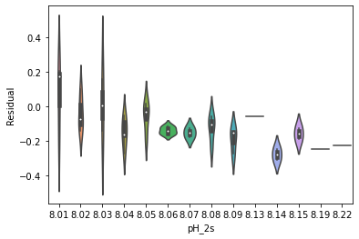

```python
grad_descent(coral_dat, pH, 1000, 0.0001, 0, 'yes')

a1 = 0.22080397
a2 = 0.7962654
a3 = -0.13454225
a4 = 0.25364617

df['Sr/Ca'] = abs(df['Sr/Ca'])
df['Mg/Ca'] = abs(df['Mg/Ca'])

df['PredictedpH'] = a1*(df['Sr/Ca']) + a2*(df['d13C']) + a3*(df['Mg/Ca']) + a4*(df['Ba/Ca'])
df['Residual'] = df['PredictedpH'] - df['pH_2s']



df['pH_Score'] = np.where(df['pH_2s'] > 8.0, 'High', 'Low')
tempdf = [x for _, x in df.groupby(by=["pH_Score"])]
highdf = tempdf[0]
l1 = sb.violinplot(x='pH_2s', y='Residual', data=highdf, figsize=(15,10))
print('pH = {}*Sr + {}*d13C +{}*Mg + {}*Ba'.format(a1, a2, a3, a4))
```

### Machine Learning Results After 1000 Iterations

- After 1000 iterations we see that the y-axis Residuals gets lower, so the accuracy of our multivariate regression have improved after increasing the number of iterations the algorithm is given to run.
- The applications of machine learning are endless, and can be used to predict a dependent variable given an independent or multiple independent variables.

# References

(1) Wei, G., M.T. McCulloch, G. Mortimer, W. Deng, and L. Xie. 2009. Evidence for ocean acidification in the Great Barrier Reef of Australia. Geochimica et Cosmochimica Acta, vol. 73, pp. 2332-2346. doi:10.1016/j.gca.2009.02.009

(2) Donner SD, Rickbeil GJM, Heron SF (2017) A new, high-resolution global mass coral bleaching database. PLoS ONE 12(4): e0175490. https://doi.org/10.1371/journal.pone.0175490